# Predicting Daily STOCK 1 Values at Market Close

**AUTHOR**: Vassil Dimitrov, PhD

**START DATE**: 2023-07-30

**Contacts:**

LinkedIn: linkedin.com/in/vassilDim

email: vasssildimitrov@gmail.com

1. Time series with `SARIMAX`
2. Time series with `TBATS`, which can capture more than 1 seasonal trends
3. LSTM RNN deep networks

**OUTLINE**

## MODULE 1 -- Load & Clean Data

|  | date | open | high | low | close | volume |
| --- | --- | --- | --- | --- | --- | --- |
| 0 | 1997-02-27 | 288.0002 | 288.0002 | 282.0002 | 285.1202 | 194 |
| 1 | 1997-02-28 | 282.0002 | 285.1202 | 282.0002 | 285.1202 | 25 |
| 2 | 1997-03-03 | 288.0002 | 288.0002 | 279.1202 | 279.1202 | 142 |
| 3 | 1997-03-04 | 278.8802 | 278.8802 | 278.8802 | 278.8802 | 0 |
| 4 | 1997-03-05 | 282.0002 | 285.1202 | 282.0002 | 285.1202 | 136 |

One can see that the data has several variables for which it keeps track: date of record `date`, value at opening `open`, value at closing `close`, highest daily value `high`, lowest daily value `low` and daily volume of transactions `volume`. Intuitively, `open` and `close` should be quite correlated, which will be shown in **Module 2 - EDA**.

Several steps will be taken to make sure that the data is ready for modelling:

1. Appropriate column names
2. Appropriate data types for each feature/column
   - numeric
   - datetime
3. No missing values
   - detect missing values and impute
4. No duplications

```
Feature types after cleaning:
 date      datetime64[ns]
open             float64
high             float64
low              float64
close            float64
volume             int64
dtype: object
--------------------

Number of null values for unmodified data:
 open      0
high      0
low       0
close     0
volume    0
dtype: int64
--------------------

There are a total of 244 missing business days.

The missing business days will be imputed in a forward-fill fashion.

Null values:
 open      244
high      244
low       244
close     244
volume    244
dtype: int64
```

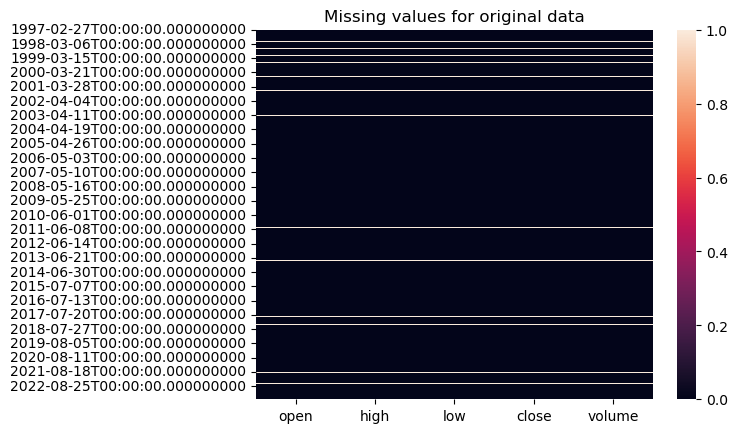

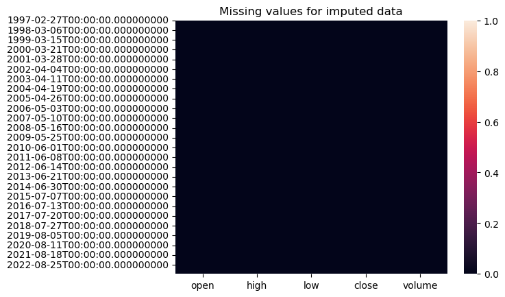

We can observe that all the features are in numeric format and the few null values present in the dataset were successfully imputed.

## MODULE 2 -- EXPLORATORY DATA ANALYSIS

The first step is to simply plot the values for `close` and `open` in order to be able to zero-in on any obvious trends.

### The Entire Data (Stock 1)

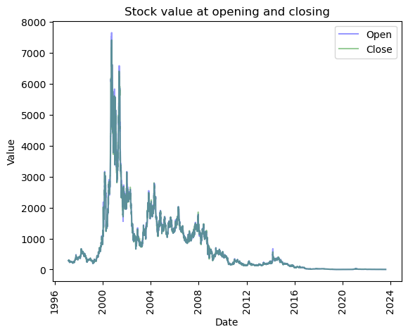

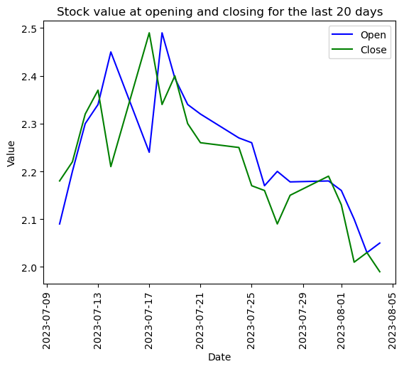

Below are the main points observed for the data:

> Quite a lot of variability initially  
> The values seem to stabilize at ~2018  
> The `close` and `open` values appear to be quite correlated. Therefore one could focus exclusively on `close` for modelling.

### Data Starting At 2020 (Stock 1)

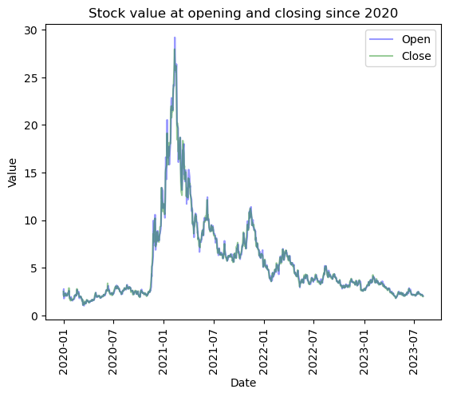

> **Only data from 2020 onwards will be considered for downstream analysis.**

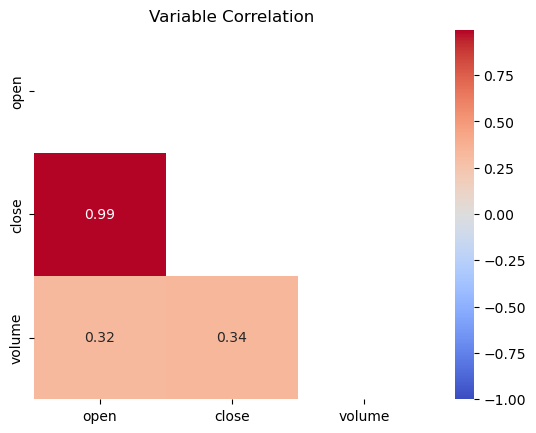

The correlation plot above confirms that `open` and `close` values are virtually perfectly correlated and only one is needed for predicting the daily value of the shares (`close`).

Let us quickly look at the distribution of the variables in the dataset.

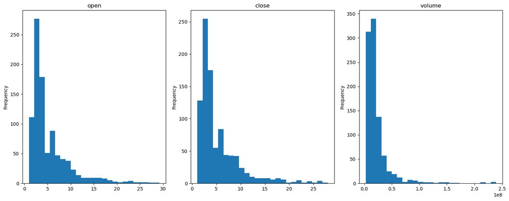

`volume`, `close`, and `open`are right-skewed. These values can be transformed by taking their log. This will make them more normally distributed, if one wished to fit a linear regression, which we will abstain from at the present moment.

Next, seasonality is determined by applying seasonal decomposition as plotted below

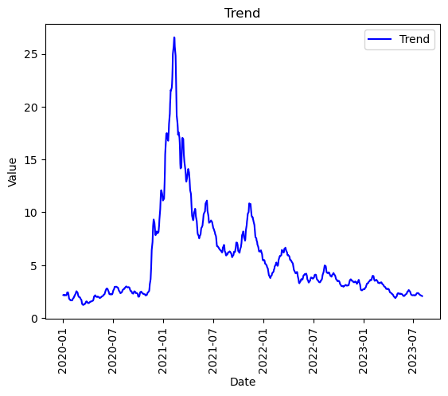

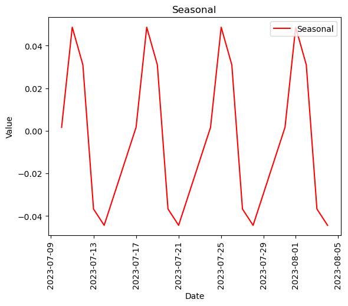

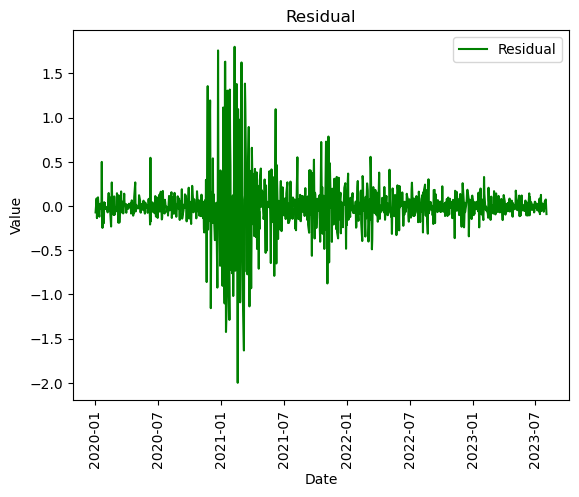

Clearly, the data is static (residuals centred around 0) even though one can observe some heteroscedasticity (RESIDUALS plot).  
There is a bit of an oscilating trend in the TREND plot that remains after factoring out the seasonal component.  
Finally, there is a clear seasonality as illustrated by the SEASONAL plot.  
The model will be optimized so that it captures as much of the trend and seasonal components in making future predictions.

## MODULE 3 -- TIME SERIES WITH SARIMAX

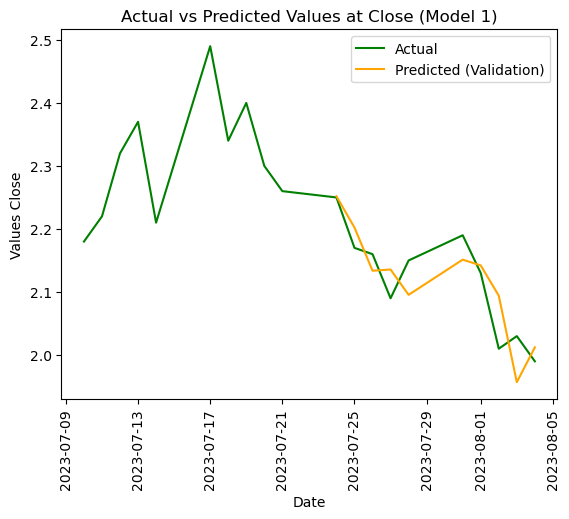

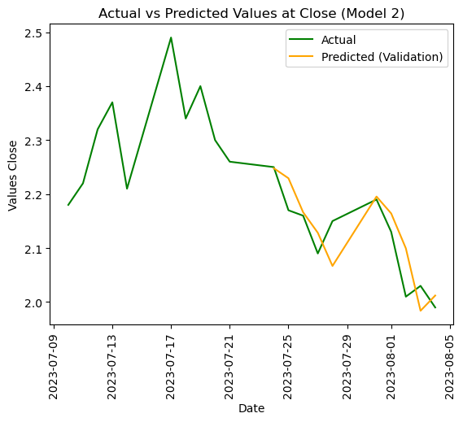

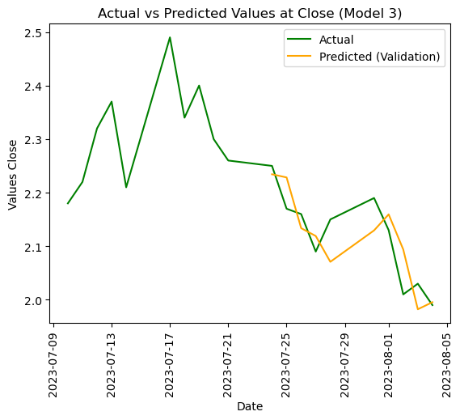

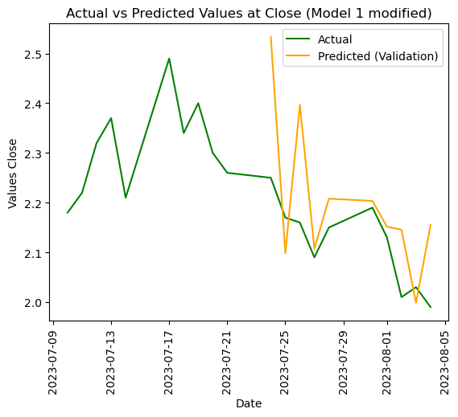

**AUTHOR**: Vassil Dimitrov, PhD

**END DATE**: 2023-08-09

</br>